# ECG Data Exploration

Sananthaa Senthamaraikannan

07-07-2026

## Why I built this

I’m a Health Data Science master’s student with a background in statistics and R, trying to move into clinical data work. My stats and programming are reasonably solid, but I had almost no background in cardiology or ECGs when I started — so I set myself a small, honest goal: take real clinical ECG recordings, learn what a data reviewer actually checks, and build a reproducible quality-control workflow in R. This write-up is me working through that, and I’ve tried to be upfront about what I understood well and what I had to look up.

The clinical context, as I understand it: in drug trials, ECGs are collected mainly to watch for cardiac safety problems, especially whether a drug lengthens the **QT interval** (there’s a regulatory guideline, ICH E14, specifically about this). A central ECG lab receives recordings from many trial sites, and **data processors** check that each recording is complete, correctly labelled, and good enough quality before the measurements are trusted. That checking step is what I set out to reproduce.

> Scope: this is a **data-quality** project, not clinical diagnosis. I am not qualified to interpret ECGs medically, and nothing here is clinical judgement. It’s about the data.

## What I learned about the signal

Every heartbeat shows up as a shape called a **PQRST** complex. Once I could recognise it, the rest made more sense:

- the **P wave** is a small bump (the atria firing),
- the **QRS complex** is the big spike (the main pumping chambers firing — easiest to detect automatically because it’s so tall),
- the **T wave** is the rounded bump after it (the heart resetting electrically).

Reviewers care about the timing between these — the intervals. I put the table below together while learning. I’m treating these as *typical reference ranges*, not clinical thresholds: they vary by source, sex, age and correction formula, so I’ve kept that framing throughout.

| Interval | What it measures | Typical adult range | Why it matters |
| --- | --- | --- | --- |
| RR | time between beats | sets the heart rate | HR = 60 / RR; needed to correct QT |
| PR | P start to QRS start | 120-200 ms | conduction timing |
| QRS | width of the spike | < 120 ms | ventricular conduction |
| QT | QRS start to T end | ~350-450 ms | the main drug-safety number |
| QTc | QT corrected for HR | < ~450-470 ms | what ICH E14 focuses on |

One thing I found interesting: QT has to be *corrected* for heart rate before you can compare it, because it naturally shortens when the heart beats faster. The classic fix is Bazett’s formula (QTc = QT / sqrt(RR)), which I read tends to over-correct at high heart rates — so even the “standard” method has known weaknesses.

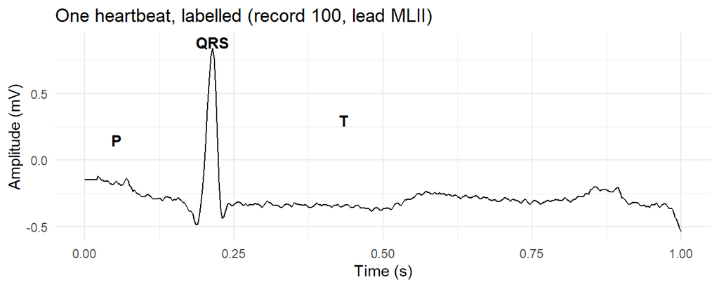

*Plotting one beat and labelling P, QRS and T myself was where the theory actually clicked.*

## The data I used

| record | leads | samples | duration_s |
| --- | --- | --- | --- |
| mitbih_100_clean | MLII, V5 | 3601 | 10 |
| mitbih_108_noisy | MLII, V5 | 3601 | 10 |

I used the **MIT-BIH Arrhythmia Database** (Moody and Mark 2001), hosted on PhysioNet (Goldberger et al. 2000) — two-lead ECG recorded at 360 Hz. The recordings come in a special format (not plain CSV), so I learned to export them with the `wfdb` reader (MIT Laboratory for Computational Physiology, n.d.). I picked two records on purpose: record 100 is clean, and record 108 has real noise and baseline shifts — so I’d have one recording that should pass and one that shouldn’t. For validation I also used record 100’s full 30-minute signal, which comes with beats labelled by cardiologists.

## How my QA check works

For each recording, and each of the two leads, my routine checks a few things a reviewer would care about: whether a lead has **dropped out** (flat signal), whether there’s a **flatline segment**, and whether there’s **too much noise** (measured as large jumps between consecutive samples). It then estimates heart rate from the detected beats and flags it if it comes out physiologically implausible. A record only passes if nothing trips. All of this is written in R using the tidyverse (Wickham et al. 2019).

## What it found

| record | n_flags | status | flags |
| --- | --- | --- | --- |
| mitbih_100_clean | 0 | PASS | PASS |
| mitbih_108_noisy | 1 | REVIEW | HR ~21 bpm outside plausible resting range |

Record 100 passed everything, as expected for a clean recording. Record 108 got flagged — and *how* it got flagged is the part I found most interesting, and honestly didn’t plan.

It didn’t trip the noise flag directly. Instead it produced an impossible heart rate. When I dug into why, it made sense: record 108 is noisy enough that my beat detector gets confused, misses beats, and the heart-rate calculation built on top of that comes out as nonsense. So a problem in the raw signal quietly turned into a wrong number downstream.

That felt like a genuinely useful lesson about clinical data — a suspicious value isn’t always wrong *at* that value; sometimes it’s a symptom of a data-quality problem further up. A reviewer who just saw “heart rate = 21” and corrected the number would miss the real issue, which is the noise. I’d rather my tool surface that than hide it.

*(Interactive versions of each trace are saved next to this report as `wave_<record>.html`, so the noise in record 108 can be scrolled through and seen.)*

## Checking whether my beat detector actually works

The part I was least sure about was my R-peak detector — it’s a simple threshold method, and I wanted to know if it was actually any good rather than just assuming. Record 100 comes with **2,273 beats labelled by cardiologists**, so I could check my detected beats against theirs. I matched each detected peak to an expert beat within 50 ms and computed two things: **sensitivity** (of the real beats, how many did I catch?) and **precision / PPV** (of the beats I flagged, how many were real?).

| detector | expert_beats | detected | TP | FP | FN | sensitivity | PPV |
| --- | --- | --- | --- | --- | --- | --- | --- |
| Global threshold (baseline) | 2273 | 1861 | 1860 | 1 | 413 | 0.8183 | 0.9995 |
| Moving-window (improved) | 2273 | 2272 | 2271 | 1 | 2 | 0.9991 | 0.9996 |

My first attempt used one fixed threshold for the whole recording. It was very precise (almost everything it flagged was a real beat) but its sensitivity was only about 82% — it was *missing* 413 beats. That surprised me, so I looked at where the misses were: the signal amplitude drifts up and down over the 30 minutes, and a single threshold set from the whole-record maximum ends up too high during the quieter stretches, so those beats slip under it.

Once I understood that, the fix was fairly natural — use a **moving-window threshold** that adapts to the local signal instead of one global cut-off. That pushed sensitivity up to about 99.9% while keeping precision basically the same. Going from diagnosing *why* it failed to fixing it was the most satisfying part of the project.

I also built a small interactive viewer (`ecg_viewer.html`) so you can flip between the two detectors and watch the missed beats appear and disappear.

## What I’d flag about my own work

I want to be honest about the limits, because pretending otherwise defeats the point:

- My beat detector is deliberately simple. Real ECG labs use validated algorithms and still have a human check the results. Mine is a learning exercise, not production-grade.
- I didn’t actually *measure* the PR/QT/QTc intervals from the signal — I only discussed them. A real workflow would bring those in from validated measurements.
- I tuned the improved detector’s settings on record 100 and didn’t test them on other records, so I can’t claim they’d generalise. That’s exactly what I’d test next.

The one bit of professional framing I tried to respect: clinical data work follows data-integrity principles (I came across “ALCOA+”). My outputs are attributable and dated, the scripts make everything reproducible, and the QA flags never overwrite the raw signal — the original data stays intact and the review is logged separately. That felt like the right habit to build early.

## References

Goldberger, Ary L., Luis A. N. Amaral, Leon Glass, Jeffrey M. Hausdorff, Plamen Ch. Ivanov, Roger G. Mark, Joseph E. Mietus, George B. Moody, Chung-Kang Peng, and H. Eugene Stanley. 2000. “PhysioBank, PhysioToolkit, and PhysioNet: Components of a New Research Resource for Complex Physiologic Signals.” *Circulation* 101 (23): e215–20.

MIT Laboratory for Computational Physiology. n.d. “wfdb-python: Native Python WFDB Package.” https://github.com/MIT-LCP/wfdb-python.

Moody, George B., and Roger G. Mark. 2001. “The Impact of the MIT-BIH Arrhythmia Database.” *IEEE Engineering in Medicine and Biology Magazine* 20 (3): 45–50. https://doi.org/10.1109/51.932724.

Wickham, Hadley et al. 2019. “Welcome to the tidyverse.” *Journal of Open Source Software* 4 (43): 1686. https://doi.org/10.21105/joss.01686.